# Capstone Project-1

## Predictive modelling of customer bookings-Flight tickets

*****************************************************************************************************************************

## Understanding customer behaviour is crucial to improve sales and customer satisfaction. Predicting customer behaviour in flight ticket booking is a challenging task due to the dynamic nature of the travel industry and the wide range of factors that influence customer purchasing decisions.

## The aim of this project is to analyze customer behaviour in flight ticket booking by analyzing historical data on flight ticket purchases and customer demographics and create a predictive model

*****************************************************************************************************************************

# Loading the required Libraries

```python
# Standard Libraries
import pandas as pd
import numpy as np
import os

# For visualizations
import matplotlib.pyplot as plt
import seaborn as sns
%matplotlib inline
import plotly.offline as py
py.init_notebook_mode(connected=True)
import plotly.graph_objs as go
import plotly.tools as tls
import plotly.express as px


# Data-Prep
from sklearn.preprocessing import StandardScaler
from imblearn.over_sampling import SMOTE

# Model Buidling and metrics
from sklearn.model_selection import train_test_split
from sklearn.ensemble import RandomForestClassifier
from sklearn.metrics import confusion_matrix , classification_report , accuracy_score
from sklearn.model_selection import cross_val_score
```

# 1.Loading the dataset

```python
data = pd.read_csv("C:\\python_class\\customer_booking.csv", encoding="ISO-8859-1")
data.head()
```

|  | num_passengers | sales_channel | trip_type | purchase_lead | length_of_stay | flight_hour | flight_day | route | booking_origin | wants_extra_baggage | wants_preferred_seat | wants_in_flight_meals | flight_duration | booking_complete |
| --- | --- | --- | --- | --- | --- | --- | --- | --- | --- | --- | --- | --- | --- | --- |
| 0 | 2 | Internet | RoundTrip | 262 | 19 | 7 | Sat | AKLDEL | New Zealand | 1 | 0 | 0 | 5.52 | 0 |
| 1 | 1 | Internet | RoundTrip | 112 | 20 | 3 | Sat | AKLDEL | New Zealand | 0 | 0 | 0 | 5.52 | 0 |
| 2 | 2 | Internet | RoundTrip | 243 | 22 | 17 | Wed | AKLDEL | India | 1 | 1 | 0 | 5.52 | 0 |
| 3 | 1 | Internet | RoundTrip | 96 | 31 | 4 | Sat | AKLDEL | New Zealand | 0 | 0 | 1 | 5.52 | 0 |
| 4 | 2 | Internet | RoundTrip | 68 | 22 | 15 | Wed | AKLDEL | India | 1 | 0 | 1 | 5.52 | 0 |

## To provide more context, below is a more detailed data description, explaining exactly what each column means:

- `num_passengers` = number of passengers travelling
- `sales_channel` = sales channel booking was made on
- `trip_type` = trip Type (Round Trip, One Way, Circle Trip)
- `purchase_lead` = number of days between travel date and booking date
- `length_of_stay` = number of days spent at destination
- `flight_hour` = hour of flight departure
- `flight_day` = day of week of flight departure
- `route` = origin -> destination flight route
- `booking_origin` = country from where booking was made
- `wants_extra_baggage` = if the customer wanted extra baggage in the booking
- `wants_preferred_seat` = if the customer wanted a preferred seat in the booking
- `wants_in_flight_meals` = if the customer wanted in-flight meals in the booking
- `flight_duration` = total duration of flight (in hours)
- `booking_complete` = flag indicating if the customer completed the booking

```python
data.info()
```

```
<class 'pandas.core.frame.DataFrame'>
RangeIndex: 50000 entries, 0 to 49999
Data columns (total 14 columns):
 #   Column                 Non-Null Count  Dtype
---  ------                 --------------  -----
 0   num_passengers         50000 non-null  int64
 1   sales_channel          50000 non-null  object
 2   trip_type              50000 non-null  object
 3   purchase_lead          50000 non-null  int64
 4   length_of_stay         50000 non-null  int64
 5   flight_hour            50000 non-null  int64
 6   flight_day             50000 non-null  object
 7   route                  50000 non-null  object
 8   booking_origin         50000 non-null  object
 9   wants_extra_baggage    50000 non-null  int64
 10  wants_preferred_seat   50000 non-null  int64
 11  wants_in_flight_meals  50000 non-null  int64
 12  flight_duration        50000 non-null  float64
 13  booking_complete       50000 non-null  int64
dtypes: float64(1), int64(8), object(5)
memory usage: 5.3+ MB
```

### Total rows = 50,000

### Total columns = 14

### Total columns with "object" Dtype = 5

### Total columns with "int" Dtype = 8

### Total columns with "float" Dtype = 1

```python
data.describe()
```

|  | num_passengers | purchase_lead | length_of_stay | flight_hour | wants_extra_baggage | wants_preferred_seat | wants_in_flight_meals | flight_duration | booking_complete |
| --- | --- | --- | --- | --- | --- | --- | --- | --- | --- |
| count | 50000.000000 | 50000.000000 | 50000.00000 | 50000.00000 | 50000.000000 | 50000.000000 | 50000.000000 | 50000.000000 | 50000.000000 |
| mean | 1.591240 | 84.940480 | 23.04456 | 9.06634 | 0.668780 | 0.296960 | 0.427140 | 7.277561 | 0.149560 |
| std | 1.020165 | 90.451378 | 33.88767 | 5.41266 | 0.470657 | 0.456923 | 0.494668 | 1.496863 | 0.356643 |
| min | 1.000000 | 0.000000 | 0.00000 | 0.00000 | 0.000000 | 0.000000 | 0.000000 | 4.670000 | 0.000000 |
| 25% | 1.000000 | 21.000000 | 5.00000 | 5.00000 | 0.000000 | 0.000000 | 0.000000 | 5.620000 | 0.000000 |
| 50% | 1.000000 | 51.000000 | 17.00000 | 9.00000 | 1.000000 | 0.000000 | 0.000000 | 7.570000 | 0.000000 |
| 75% | 2.000000 | 115.000000 | 28.00000 | 13.00000 | 1.000000 | 1.000000 | 1.000000 | 8.830000 | 0.000000 |
| max | 9.000000 | 867.000000 | 778.00000 | 23.00000 | 1.000000 | 1.000000 | 1.000000 | 9.500000 | 1.000000 |

# 2.Data-preprocessing

## 2.1.Checking for duplicate values

```python
data.duplicated().sum()
```

```
719
```

### 719 records are duplicated. We will remove all the duplicated except the last one.

```python
# Extract duplicate rows
data.loc[data.duplicated(), :]
```

|  | num_passengers | sales_channel | trip_type | purchase_lead | length_of_stay | flight_hour | flight_day | route | booking_origin | wants_extra_baggage | wants_preferred_seat | wants_in_flight_meals | flight_duration | booking_complete |
| --- | --- | --- | --- | --- | --- | --- | --- | --- | --- | --- | --- | --- | --- | --- |
| 196 | 5 | Internet | RoundTrip | 206 | 17 | 13 | Sun | AKLKUL | Malaysia | 1 | 0 | 0 | 8.83 | 0 |
| 316 | 5 | Internet | RoundTrip | 206 | 17 | 13 | Sun | AKLKUL | Malaysia | 1 | 0 | 0 | 8.83 | 0 |
| 384 | 5 | Internet | RoundTrip | 206 | 17 | 13 | Sun | AKLKUL | Malaysia | 1 | 0 | 0 | 8.83 | 0 |
| 456 | 1 | Internet | RoundTrip | 30 | 85 | 15 | Fri | AKLKUL | Malaysia | 1 | 0 | 0 | 8.83 | 1 |
| 513 | 3 | Internet | RoundTrip | 109 | 20 | 4 | Tue | AKLKUL | Singapore | 1 | 0 | 1 | 8.83 | 0 |
| ... | ... | ... | ... | ... | ... | ... | ... | ... | ... | ... | ... | ... | ... | ... |
| 49852 | 2 | Internet | RoundTrip | 204 | 6 | 14 | Tue | PENTPE | Malaysia | 1 | 0 | 0 | 4.67 | 0 |
| 49902 | 1 | Mobile | RoundTrip | 106 | 6 | 11 | Fri | PENTPE | Taiwan | 1 | 0 | 0 | 4.67 | 0 |
| 49934 | 1 | Internet | RoundTrip | 2 | 6 | 3 | Thu | PENTPE | Malaysia | 0 | 0 | 1 | 4.67 | 0 |
| 49944 | 1 | Internet | RoundTrip | 2 | 6 | 3 | Thu | PENTPE | Malaysia | 0 | 0 | 1 | 4.67 | 0 |
| 49961 | 1 | Internet | RoundTrip | 30 | 6 | 7 | Thu | PENTPE | Taiwan | 0 | 0 | 0 | 4.67 | 0 |

719 rows × 14 columns

```python
# Use keep='last' to keep the last occurrence
data = data.drop_duplicates(keep='last')
```

```python
data.duplicated().sum()
```

```
0
```

## 2.2.Checking for null values

```python
data.isnull().sum()
```

```
num_passengers           0
sales_channel            0
trip_type                0
purchase_lead            0
length_of_stay           0
flight_hour              0
flight_day               0
route                    0
booking_origin           0
wants_extra_baggage      0
wants_preferred_seat     0
wants_in_flight_meals    0
flight_duration          0
booking_complete         0
dtype: int64
```

### No null values in our dataset

## 2.2.Feature Encoding

### Machine learning models can only work with numerical values. For this reason, it is necessary to transform the categorical values of the relevant features into numerical ones. This process is called feature encoding.

```python
# Separating categorical and numerical columns
data_categorical = data.select_dtypes(include="object")
data_numerical = data.select_dtypes(exclude="object")
```

```python
data_categorical.head()
```

|  | sales_channel | trip_type | flight_day | route | booking_origin |
| --- | --- | --- | --- | --- | --- |
| 0 | Internet | RoundTrip | Sat | AKLDEL | New Zealand |
| 1 | Internet | RoundTrip | Sat | AKLDEL | New Zealand |
| 2 | Internet | RoundTrip | Wed | AKLDEL | India |
| 3 | Internet | RoundTrip | Sat | AKLDEL | New Zealand |
| 4 | Internet | RoundTrip | Wed | AKLDEL | India |

```python
for col in data_categorical:
    print(data_categorical[col].value_counts())
    print("\n")
```

```
Internet    43917
Mobile       5364
Name: sales_channel, dtype: int64


RoundTrip     48779
OneWay          386
CircleTrip      116
Name: trip_type, dtype: int64


Mon    7988
Wed    7562
Tue    7558
Thu    7323
Fri    6685
Sun    6442
Sat    5723
Name: flight_day, dtype: int64


AKLKUL    2620
PENTPE     912
MELSGN     833
ICNSIN     793
DMKKIX     729
          ...
AKLHGH       1
JEDPDG       1
JEDPEN       1
DACPEK       1
MRUXIY       1
Name: route, Length: 799, dtype: int64


Australia               17691
Malaysia                 7055
South Korea              4502
Japan                    3819
China                    3284
                        ...
Panama                      1
Tonga                       1
Tanzania                    1
Bulgaria                    1
Svalbard & Jan Mayen        1
Name: booking_origin, Length: 104, dtype: int64
```

### In this technique, the categorical parameters will prepare separate columns for each unique value given.

```python
data_categorical.columns
```

```
Index(['sales_channel', 'trip_type', 'flight_day', 'route', 'booking_origin'], dtype='object')
```

```python
# loop to apply one hot encoding
columns = ['sales_channel', 'trip_type', 'flight_day', 'route', 'booking_origin']
for value in columns:
    data_categorical=pd.get_dummies(data_categorical, columns=[value],drop_first=True)      # dropping the first
```

```python
data_categorical.shape               # new columns are added
```

```
(49281, 910)
```

```python
data_categorical.head()
```

|  | sales_channel_Mobile | trip_type_OneWay | trip_type_RoundTrip | flight_day_Mon | flight_day_Sat | flight_day_Sun | flight_day_Thu | flight_day_Tue | flight_day_Wed | route_AKLHGH | ... | booking_origin_Timor-Leste | booking_origin_Tonga | booking_origin_Tunisia | booking_origin_Turkey | booking_origin_Ukraine | booking_origin_United Arab Emirates | booking_origin_United Kingdom | booking_origin_United States | booking_origin_Vanuatu | booking_origin_Vietnam |
| --- | --- | --- | --- | --- | --- | --- | --- | --- | --- | --- | --- | --- | --- | --- | --- | --- | --- | --- | --- | --- | --- |
| 0 | 0 | 0 | 1 | 0 | 1 | 0 | 0 | 0 | 0 | 0 | ... | 0 | 0 | 0 | 0 | 0 | 0 | 0 | 0 | 0 | 0 |
| 1 | 0 | 0 | 1 | 0 | 1 | 0 | 0 | 0 | 0 | 0 | ... | 0 | 0 | 0 | 0 | 0 | 0 | 0 | 0 | 0 | 0 |
| 2 | 0 | 0 | 1 | 0 | 0 | 0 | 0 | 0 | 1 | 0 | ... | 0 | 0 | 0 | 0 | 0 | 0 | 0 | 0 | 0 | 0 |
| 3 | 0 | 0 | 1 | 0 | 1 | 0 | 0 | 0 | 0 | 0 | ... | 0 | 0 | 0 | 0 | 0 | 0 | 0 | 0 | 0 | 0 |
| 4 | 0 | 0 | 1 | 0 | 0 | 0 | 0 | 0 | 1 | 0 | ... | 0 | 0 | 0 | 0 | 0 | 0 | 0 | 0 | 0 | 0 |

5 rows × 910 columns

# 3.EDA

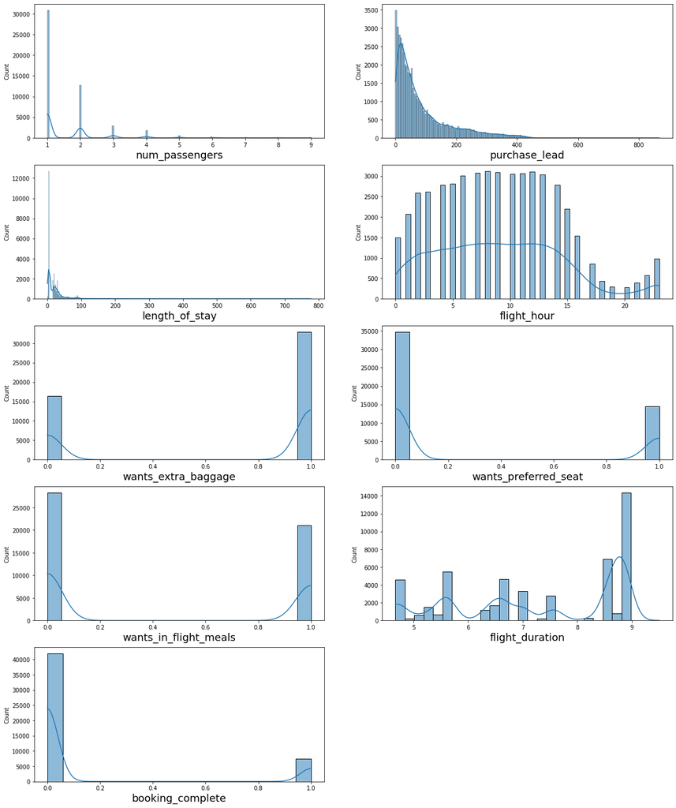

```python
#Checking distribution of the data
plt.figure(figsize=(20,25))
for i, col in enumerate(data_numerical.columns):
    plt.subplot(5, 2, i+1)
    sns.histplot(data_numerical[col] , kde=True)
    plt.xlabel(col , fontsize=18)
plt.show()
```

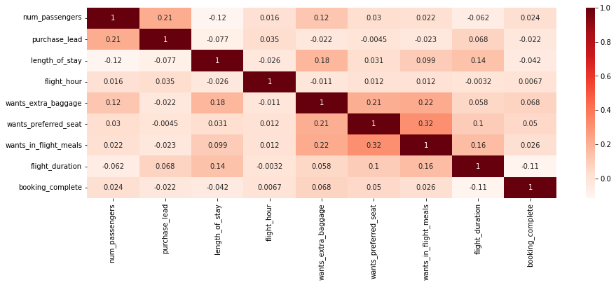

```python
# Plotting heatmap
plt.figure(figsize=(15,5))
sns.heatmap(data_numerical.corr() , annot=True, cmap="Reds")
plt.show()
```

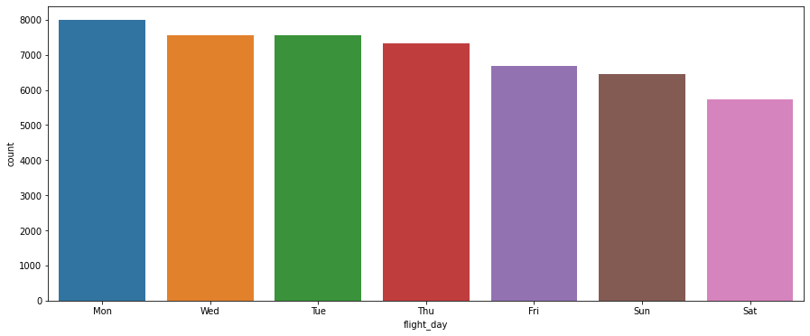

```python
# No. of flights on each day of the week
plt.figure(figsize=(15,6))
sns.countplot(x = "flight_day", data=data, order=data["flight_day"].value_counts().index)
plt.show()
```

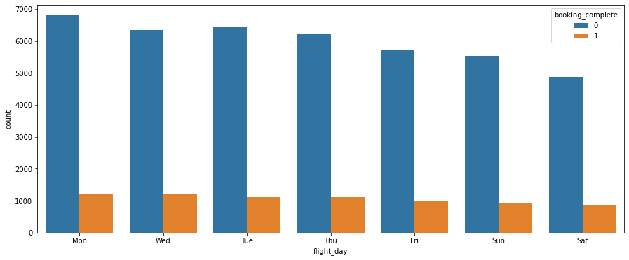

```python
# No. of flights on each day of the week
plt.figure(figsize=(15,6))
sns.countplot(x = "flight_day",hue = "booking_complete", data=data, order=data["flight_day"].value_counts().index)
plt.show()
```

### No of flights is max on monday and lowest on Saturday

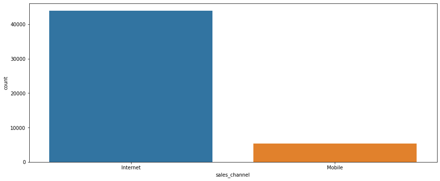

```python
# Frequently used Booking channel
plt.figure(figsize=(15,6))
sns.countplot(x = "sales_channel", data=data, order=data["sales_channel"].value_counts().index)
plt.show()
```

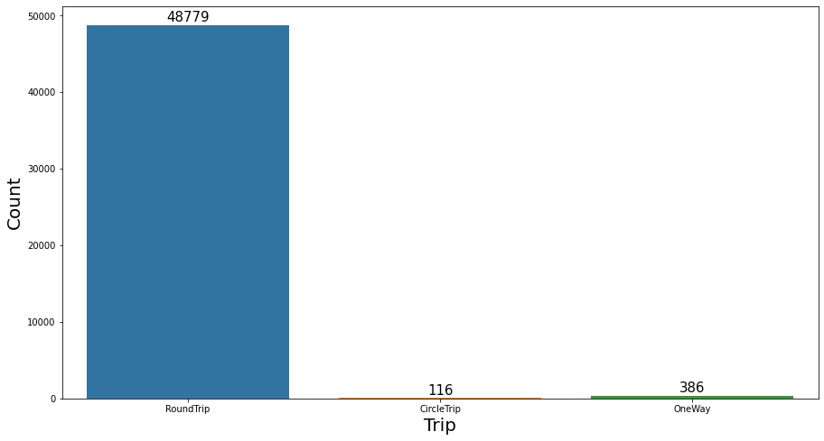

```python
# Most frequently opted trip type
plt.figure(figsize=(15,8))
plots = sns.countplot(x="trip_type",  data=data)
plt.xlabel("Trip",fontsize= 20)
plt.ylabel("Count", fontsize= 20)

for bar in plots.patches:
    plots.annotate(format(bar.get_height()),(bar.get_x() + bar.get_width() / 2,bar.get_height()),
                   ha='center', va='center',size=15, xytext=(0, 8),textcoords='offset points')
```

# Most passengers prefer to book round trip

```python
data["booking_origin"].value_counts(ascending=False)
```

```
Australia               17691
Malaysia                 7055
South Korea              4502
Japan                    3819
China                    3284
                        ...
Panama                      1
Tonga                       1
Tanzania                    1
Bulgaria                    1
Svalbard & Jan Mayen        1
Name: booking_origin, Length: 104, dtype: int64
```

# Top 10 Countries in flight bookings

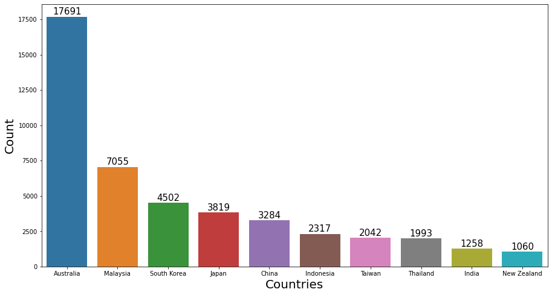

```python
plt.figure(figsize=(15,8))
plots = sns.countplot(x="booking_origin",  data=data ,order=data.booking_origin.value_counts().iloc[:10].index)
plt.xlabel("Countries",fontsize= 20)
plt.ylabel("Count", fontsize= 20)

for bar in plots.patches:
    plots.annotate(format(bar.get_height()),(bar.get_x() + bar.get_width() / 2,bar.get_height()),
                   ha='center', va='center',size=15, xytext=(0, 8),textcoords='offset points')
```